# Amkor Technology (AMKR) 기업 분석

AI 패키징의 좋은 회사, 아직은 좋은 진입점이 아닌 이유

저자

Alpha Hunter × Chimera AI

공개

2026년 8월 16일

**경고면책과 판정**

이 프로젝트는 가상 투자 시뮬레이션 목적으로 작성되었으며 실제 투자 권유가 아니다. **AMKR는 이번 검토에서 SEPA Stage 2 조건을 통과하지 못했으므로 신규 추천 종목이 아니다.**

# 1 한눈에 보는 결론

Amkor의 2Q26 실적은 강했다. 매출은 `19.0억 달러`로 전년 대비 `26%` 늘었고, 영업이익은 `2.00억 달러`, 영업이익률은 `10.5%`였다. Computing 매출은 전분기 대비 `20%` 증가했고 회사는 AI·HPC 프로그램, NVIDIA와의 다년 협력, TSMC와의 10년 첨단패키징 계약을 제시했다. 그러나 2026년 연간 CAPEX 계획은 `25~30억 달러`이고, 상반기 영업현금흐름 `3.82억 달러`보다 유형자산 지출 `6.88억 달러`가 컸다. 성장의 질은 **수요뿐 아니라 가동률과 현금회수**로 검증해야 한다. [Amkor 2Q26 공식 실적](https://ir.amkor.com/static-files/202be5d9-a98f-4eec-b33a-1ca37bbbfb29) · [공식 발표자료](https://ir.amkor.com/static-files/24ab31c3-a74b-4dde-8591-904204b5b0b9)

| 항목 | 판정 |
| --- | --- |
| 펀더멘털 | 매출·마진·EPS 가속 확인 |
| 산업 서사 | AI/HPC 첨단패키징 수요와 연결 |
| 현금흐름 | 대규모 선행 CAPEX로 자유현금흐름 압박 |
| 가격 추세 | 50일선 아래, 52주 고점 대비 약 -37% |
| 최종 | **관찰 — SEPA 불합격, 진입가격 제시 안 함** |

# 2 SEPA 트렌드 템플릿

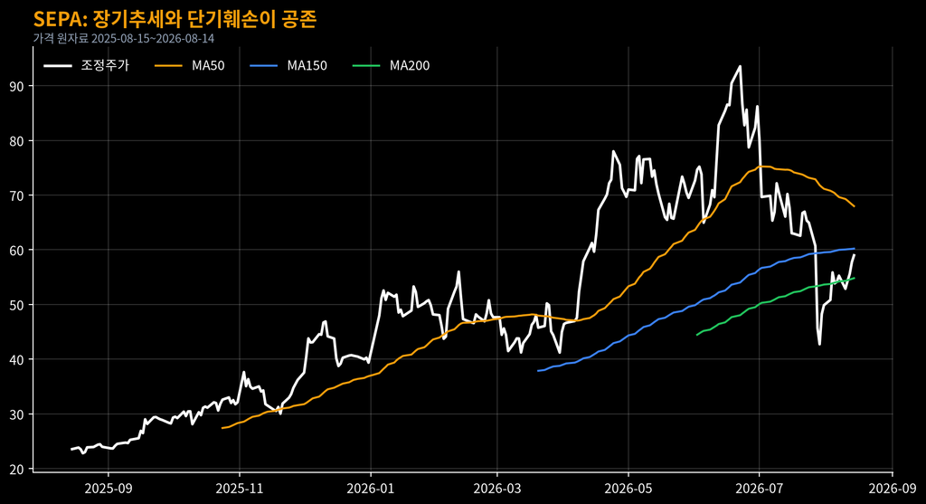

그림 1: 그림 1. AMKR 조정주가와 50·150·200일 이동평균. 8월 14일 현재 주가는 50일선 아래다.

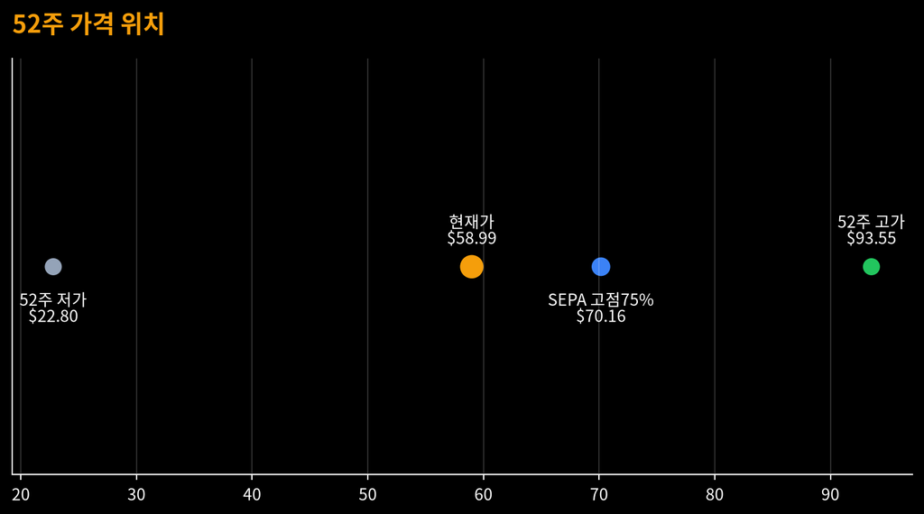

그림 2: 그림 2. 52주 저가·현재가·고가 위치. 현재가는 저점보다 높지만 고점의 75% 기준을 충족하지 못한다.

마지막 가격은 `$58.99`, MA50 `$67.98`, MA150 `$60.22`, MA200 `$54.81`이다. MA200은 한 달 전보다 상승했지만, 현재가는 MA50과 MA150 아래이고 52주 고가 `$93.55`의 `63.1%`다. 조건 4·5·7이 깨진다.

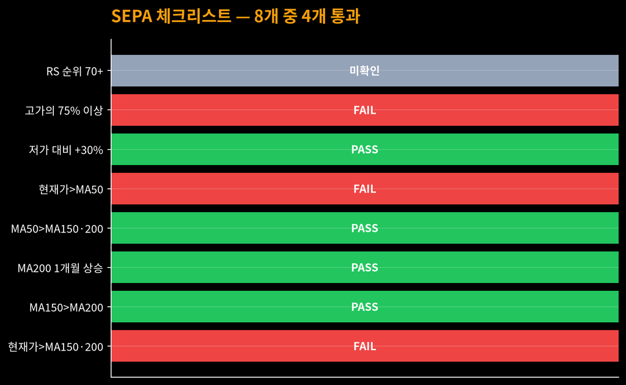

그림 3: 그림 3. SEPA 8개 조건의 기계적 판정. RS 순위는 공식 비교 데이터가 없어 미확인으로 남겼다.

# 3 실적 가속

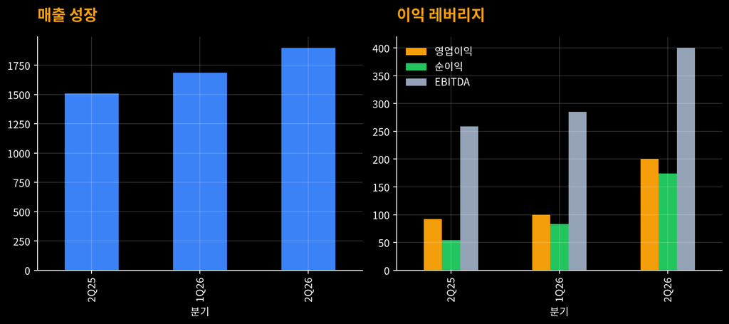

그림 4: 그림 4. Amkor 공식 2Q26 실적표의 분기 비교(백만 달러).

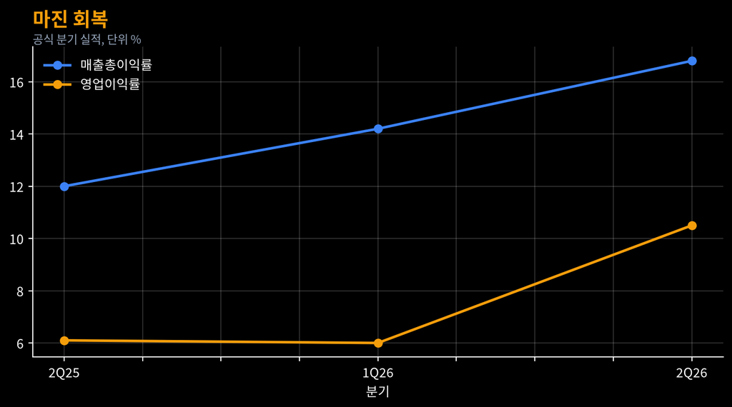

그림 5: 그림 5. 매출총이익률과 영업이익률. 가동률 개선이 마진 확대로 연결됐다.

EPS는 `$0.22 → $0.33 → $0.70`으로 확대됐다. 단, 2Q25에는 Nanium 관련 우발대가 순이익에 약 `$0.07` 포함됐다. 기저를 그대로 비교하면 오히려 2026년 개선을 과소평가할 수 있으나, 한 분기 이익을 장기 정상마진으로 외삽해서도 안 된다.

# 4 사업 믹스와 AI 연결

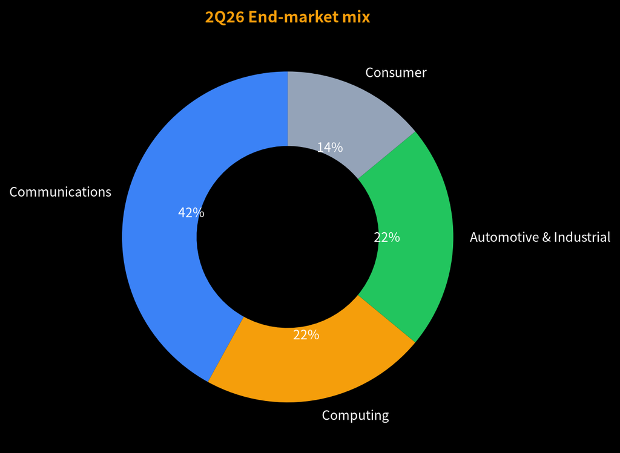

그림 6: 그림 6. 2Q26 매출 믹스. Computing은 22%이며 AI 서사가 회사 전체 매출과 동일하지는 않다.

Computing 22%에는 데이터센터뿐 아니라 인프라·PC·노트북·스토리지가 함께 포함된다. 따라서 “매출의 22%가 AI”라고 읽으면 안 된다. 확인 가능한 것은 Computing이 전분기 대비 20% 성장했고 데이터센터 수요가 강했다는 회사 설명까지다.

# 5 CAPEX와 현금흐름

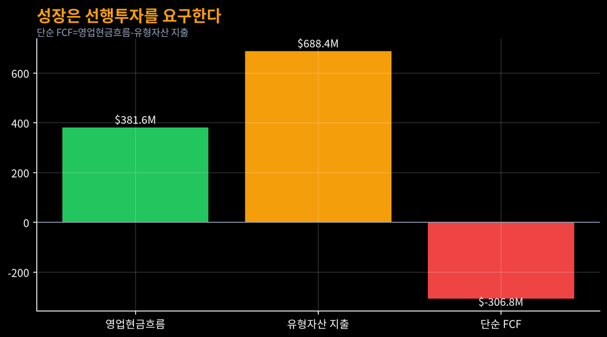

그림 7: 그림 7. 2026년 상반기 영업현금흐름과 설비투자(백만 달러). 성장투자가 내부현금창출을 앞섰다.

상반기 말 현금·단기투자는 약 `$25억`, 총부채도 약 `$25억`이다. 동시에 장기부채는 2025년 말 `$12.8억`에서 2026년 6월 `$23.3억`으로 늘었다. 연간 CAPEX 계획 `$25~30억`은 현재 EBITDA 확대가 실제 현금수익률로 이어지는지 확인해야 할 이유다.

# 6 리스크 대시보드

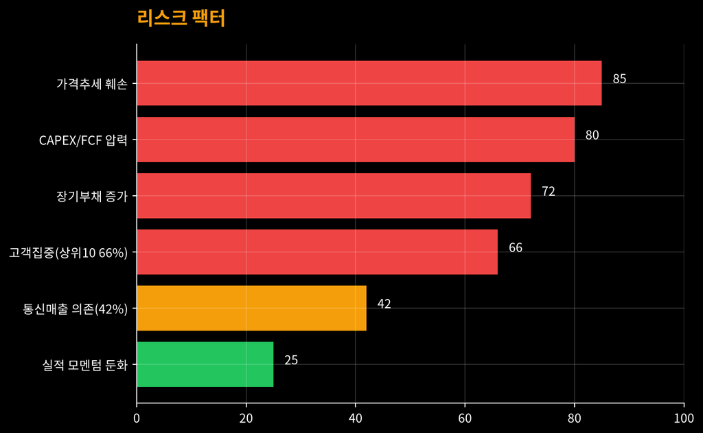

그림 8: 그림 8. Alpha Hunter 리스크 점수. 0은 낮음, 100은 높음이며 공개 수치에 대한 규칙 기반 평가다.

# 7 해자와 스토리

**해자 후보**는 세 가지다. 첨단패키징 공정경험, 글로벌 생산거점, 선도 고객과의 장기 공동투자다. 하지만 OSAT는 높은 고정비와 고객의 짧은 주문가시성, 가동률 민감도를 함께 가진다. 회사도 공시에서 높은 가동률이 만족스러운 마진에 필요하고 고객 약정이 단기적이라고 경고한다.

**피터 린치식 한 문장:** “AI 칩의 성능경쟁이 전공정에서 패키징으로 이동할수록 수혜를 받을 수 있지만, 공장을 먼저 짓고 주문을 나중에 받는 위험도 함께 커지는 회사.”

# 8 반증 조건과 재검토 규칙

이번 글은 목표가를 만들지 않는다. Stage 2가 아니기 때문이다. 다음 세 조건이 동시에 회복될 때만 재검토한다.

1. 현재가가 MA50과 MA150 위로 복귀한다.
2. 52주 고점의 75% 이상인 약 `$70.16`을 회복한다.
3. 다음 분기에서 Computing 성장과 총 가동률 개선이 마진·영업현금흐름으로 이어진다.

반대로 MA200 하향 전환, CAPEX 가이던스 상향과 현금흐름 악화의 동시 발생, 고객 프로그램 지연은 투자 가설을 약화한다.

# 9 결론

Amkor는 AI 시대의 “보이지 않는 병목”인 첨단패키징을 맡고 있고 2Q26 실적은 분명 강했다. 그러나 Alpha Hunter는 좋은 회사를 찾는 데서 멈추지 않는다. **가격이 펀더멘털을 확인해야 좋은 주식 후보가 된다.** 현재 AMKR는 장기 이동평균 구조의 일부만 살아 있고 52주 고점과 거리가 멀다. 결론은 추천이 아니라 관찰이다.

## 9.1 자료와 재현성

- [Amkor 2Q26 공식 실적 발표](https://ir.amkor.com/static-files/202be5d9-a98f-4eec-b33a-1ca37bbbfb29)
- [Amkor 2Q26 공식 프레젠테이션](https://ir.amkor.com/static-files/24ab31c3-a74b-4dde-8591-904204b5b0b9)
- [Amkor 2Q26 Form 10-Q](https://ir.amkor.com/sec-filings/sec-filing/10-q/0001047127-26-000046)
- 가격 고정본: `gems/data/amkr_price_2025-08-15_2026-08-14.csv`, Yahoo Finance chart API
- RS 순위는 공식 비교자료가 없어 미확인 처리했다. 이를 통과로 간주하지 않았다.